# Introduction to the Woodson Mapping Suite (v2.0)

# The Woodson Color Pallettes

The woodson color pallette function contains a variety of custom color pallettes generated using a cubehelix scheme (basically, creating a corkscrew through a 3-d space of red, blue, and green from dark to light). These color ramps are named, and can be called upon any time where you can enter in a vector of colors. The woodson color pallette script also includes some functions for plotting color schemes, as well.

The “Woodson Pallettes” function contains a list of named color ramps (either diverting or moving from dark to light). Accessing the colors is easy– the color ramps are stored as named lists within the fuction. You can explore the pallettes in the following ways:

```r
# Getting a list of the colors contained in a list from the
# pallette (this is how you "call" the colors in code)
wpal("black_to_light_1")
```

```
##  [1] "#000000" "#0C1D2C" "#0F433F" "#20663C" "#4A7E35" "#848941" "#BD9068"
##  [8] "#E19EA2" "#EEB9D8" "#F0DDF8"
```

If you would like to explore what any list of colors looks like in a pallette, simply use the plot_colors() function also contained within the woodson pallettes code to view a plot of the colors in question. The second argument is a string of the name of the color scheme, or the plot.

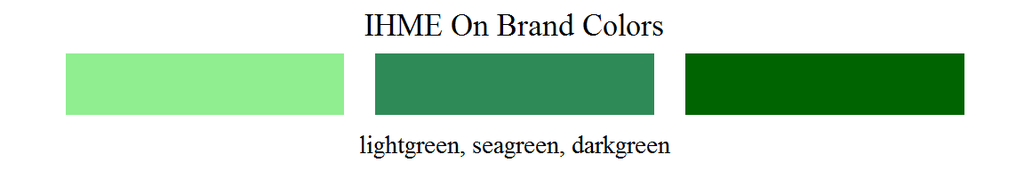

```r
plot_colors(c("lightgreen","seagreen","darkgreen"),"IHME On Brand Colors")
```

If you would like to explore any of the named pallettes, you can use a specific function to view the named pallettes native to the pallete module:

```r
view_wpal("thanksgiving")
```

```
## [1] "Plotting wpal color scheme thanksgiving"
```

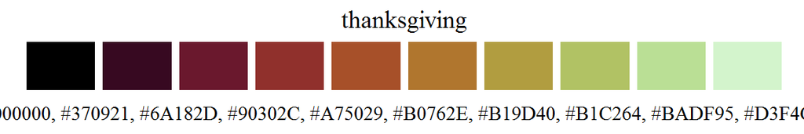

Say you want to reverse a color scheme so that dark to light is reversed– this is trivial, just use rev() on whatever color scheme you are interested in.

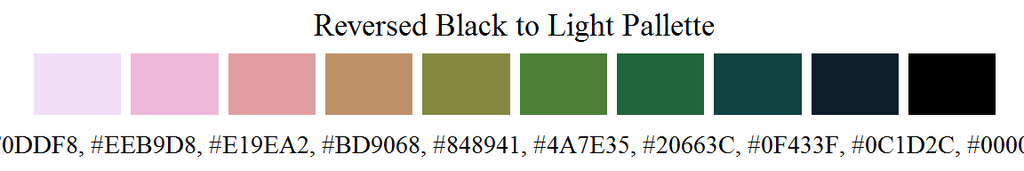

```r
plot_colors(rev(wpal("black_to_light_1")),"Reversed Black to Light Pallette")
```

If you just want a list of the names of the pallettes, without needing to plot them, you can call:

```r
# Getting a list of the names of the pallettes:
names(wpal())
```

[output not shown]

Don’t rememeber what your favorite color ramp is? No worries. You can plot out all of the color ramps available from the woodson pallettes funciton quickly!

```r
view_wpal()
```

```
## [1] "No color specified; plotting all colors"
```

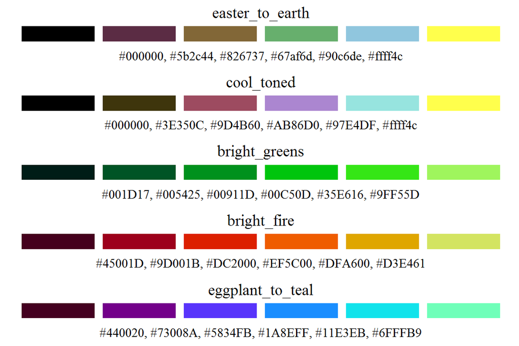

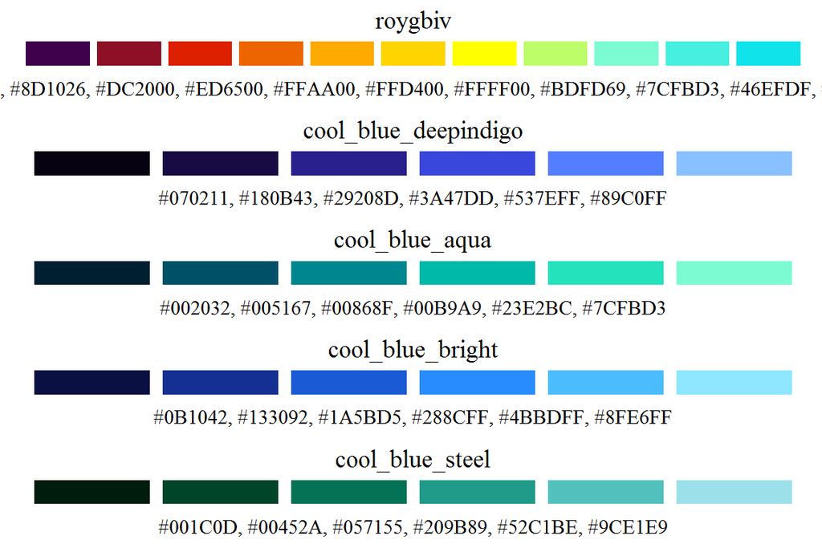

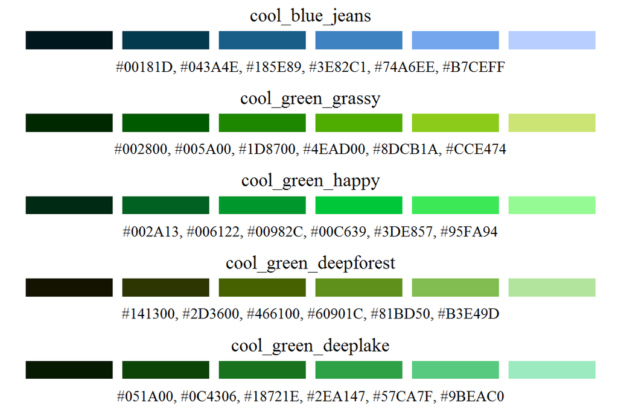

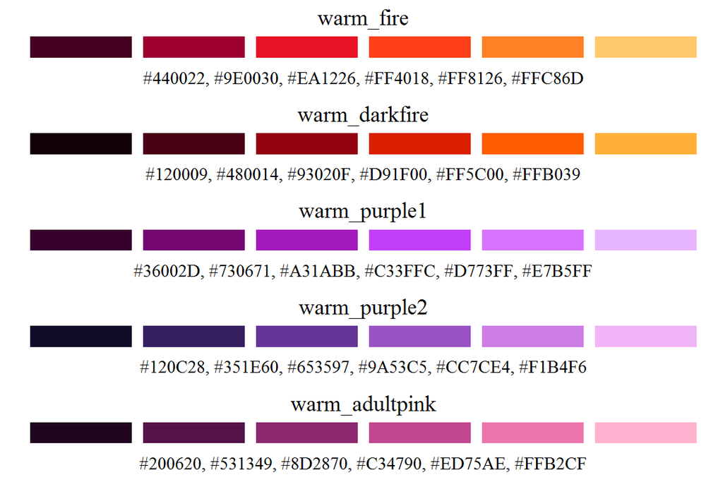

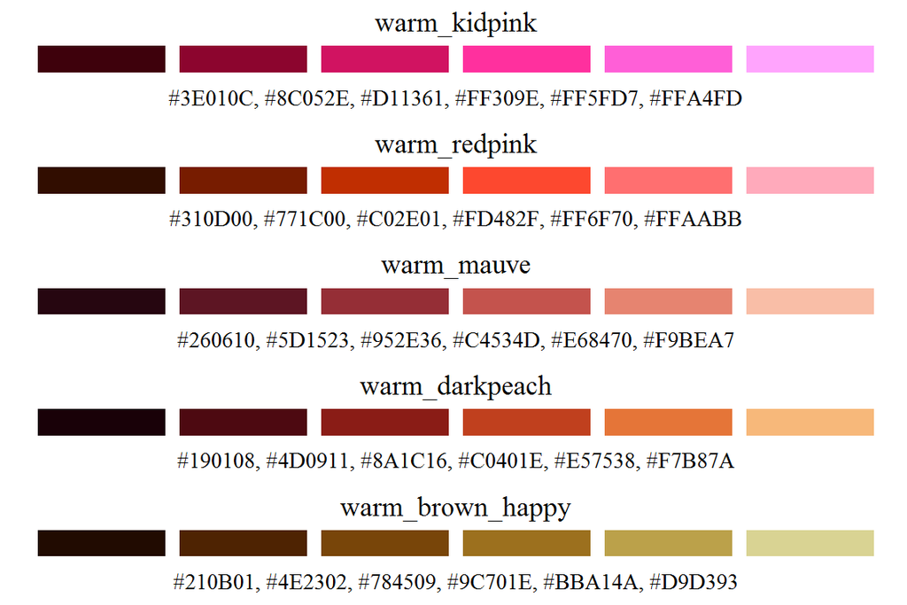

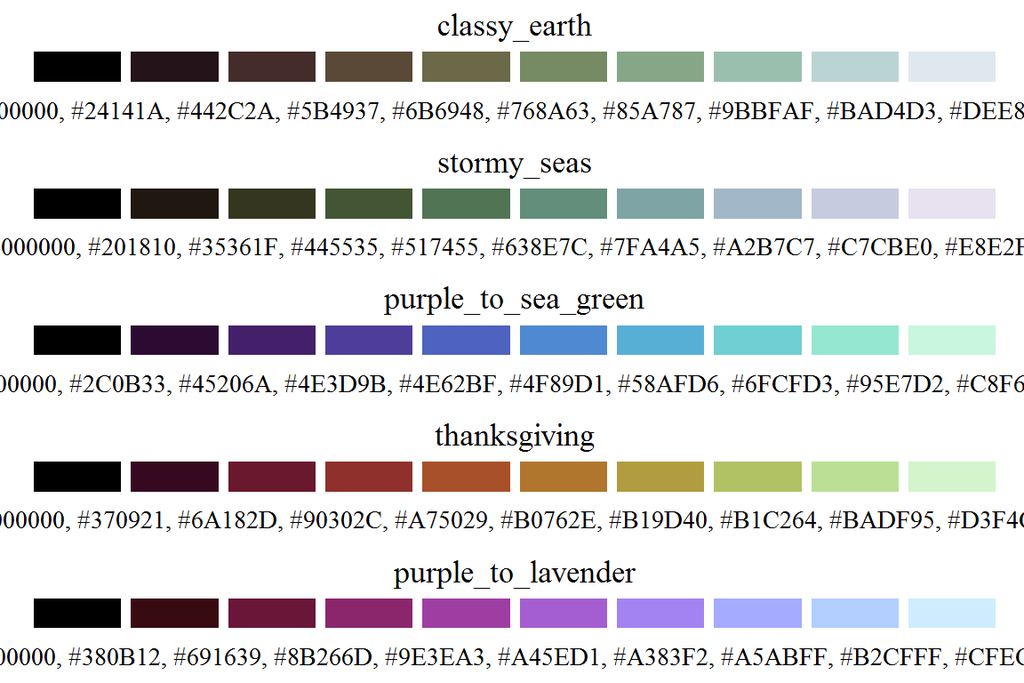

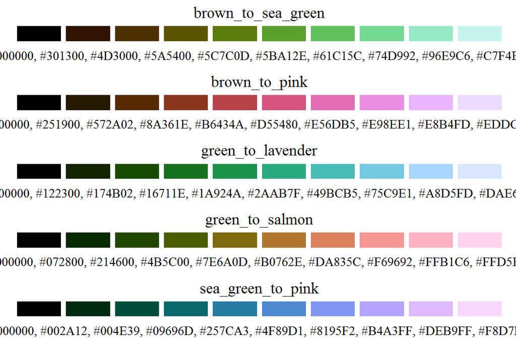

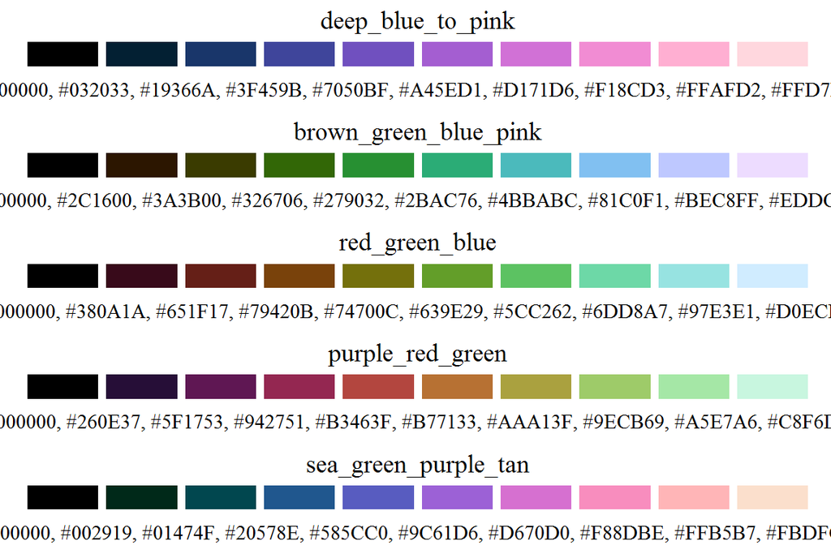

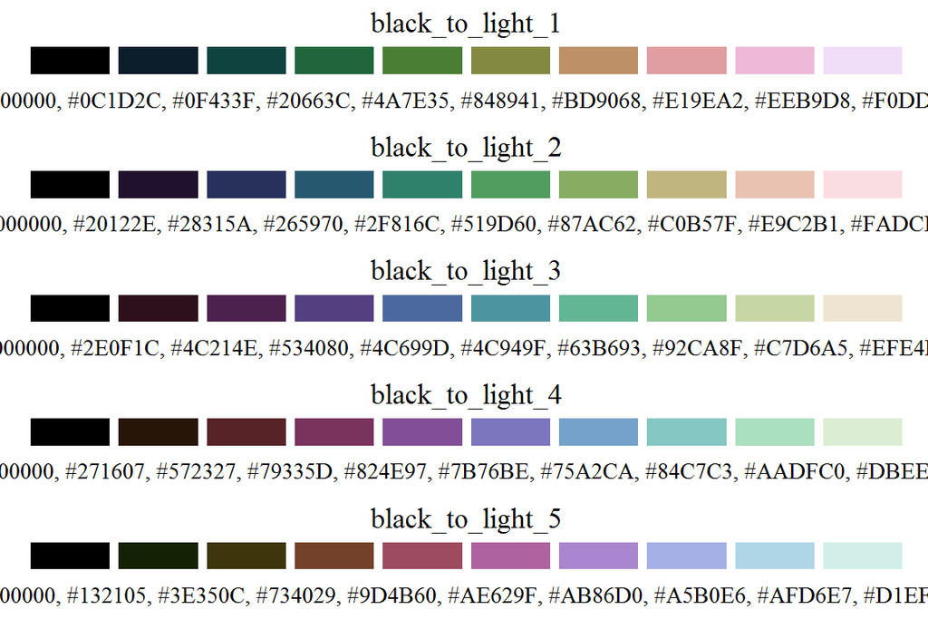

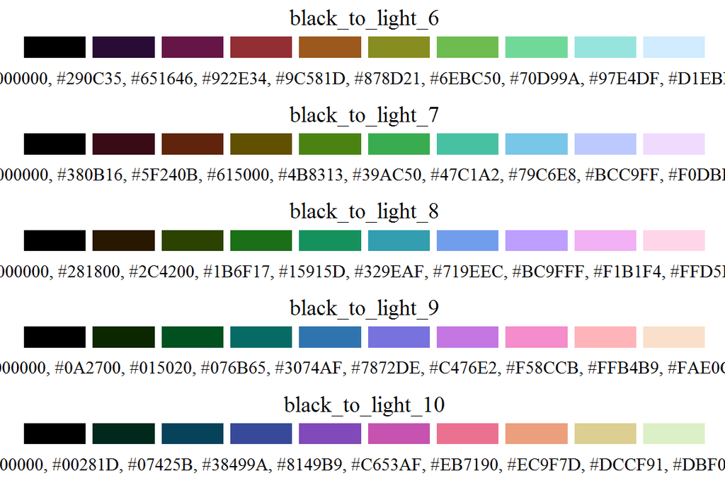

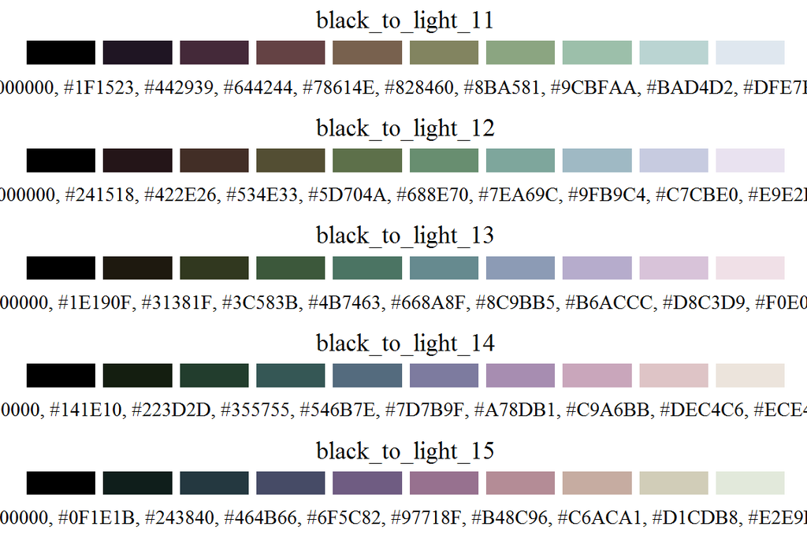

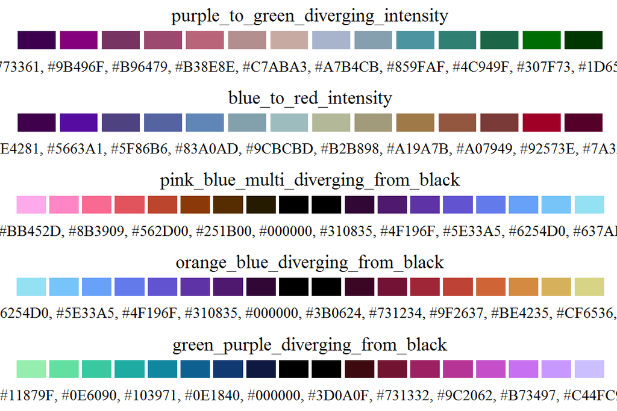

[4 more figures not shown]

Questions or Suggestions? Contact Rebecca Stubbs at stubbsrw@gmail.com